# Ratio Datasets and the Paired-Sum Rule: TPR as a Case Study

## Overview

MG2 can compute derived ratio datasets — such as test positivity rate (TPR) — by combining separate numerator and denominator data elements downloaded from DHIS2. This vignette uses bundled Lao PDR malaria surveillance data to:

1. Show how to build a TPR combined dataset from facility-level data using `build_combined_dataset()`.
2. Explain the validity rules MG2 applies when numerator or denominator values are missing for a given facility-month.
3. Quantify how many facility-months fall into each category.
4. Compare the MG2-computed TPR against the official DHIS2 indicator value for the same metric.

A companion section at the end shows how to download DHIS2 indicator values directly via the analytics API.

*Data source:* Lao PDR DHIS2 national HMIS (public demo instance, https://demos.dhis2.org/hmis), malaria programme. All demo data is bundled with MG2 and does not require a DHIS2 connection to run this vignette.

## 1 Load packages and demo data

```r
library(MG2)
library(data.table)
library(tsibble)
```

```r
library(ggplot2)
demo <- mg2_demo_dir()
list.files(demo)
```

```
#> [1] "dhis2_tpr_national_demo.rds" "Formulas_demo.xlsx"
#> [3] "malaria_demo.rds"            "metadata_demo.rds"
#> [5] "reporting_raw_demo.rds"      "tpr_demo.rds"
```

The demo directory contains three pre-built files for this vignette:

| File | Contents |
| --- | --- |
| `malaria_demo.rds` | Facility-level malaria data, all data elements, 5 years |
| `tpr_demo.rds` | MG2 combined TPR dataset built from `malaria_demo.rds` |
| `dhis2_tpr_national_demo.rds` | National TPR from DHIS2 analytics API (monthly, 2023–2026) |

## 2 What is TPR, and why compute it in MG2?

**Test positivity rate** = confirmed positive tests ÷ total tests performed. In Lao PDR’s DHIS2 instance, the official indicator *MAL - Malaria test positivity rate (Micr+RDT)* (ID: `acDxsQjnEof`) computes:

$$\text{TPR} = \frac{
\text{Microscopy positive} + \text{RDT positive}
}{
\text{Suspects tested (microscopy)} + \text{Suspects tested (RDT)}
}$$

MG2’s Combine module reconstructs this ratio from **facility-level age/sex-disaggregated data**, which enables:

- Per-facility TPR for outlier detection and champion-facility analysis
- Transparent documentation of exactly which data elements and cleaning levels were used
- Age- and sex-stratified positivity rates

The trade-off is that facility-level data is noisier and requires careful handling of partial reporting — which is the focus of this vignette.

## 3 Building the TPR definition

In the Shiny app, a ratio step is defined in the **Combine** tab by selecting the numerator and denominator data elements. Equivalent R code:

```r
steps <- list(list(
  operation   = "Ratio",
  output_name = "TPR",
  max_value   = 1,          # TPR cannot exceed 100%
  na_rm       = TRUE,       # include facilities reporting some but not all age/sex categories
  numerator = list(
    source_file    = "malaria_demo.rds",
    cleaning_level = "mad10",
    data_values    = c(
      # 6 age/sex categories × 2 data elements = 12 values
      "MAL - Microscopy positive malaria cases_0-4 years, Female",
      "MAL - Microscopy positive malaria cases_0-4 years, Male",
      "MAL - Microscopy positive malaria cases_5-14 years, Female",
      "MAL - Microscopy positive malaria cases_5-14 years, Male",
      "MAL - Microscopy positive malaria cases_15+ years, Female",
      "MAL - Microscopy positive malaria cases_15+ years, Male",
      "MAL - RDT positive malaria cases_0-4 years, Female",
      "MAL - RDT positive malaria cases_0-4 years, Male",
      "MAL - RDT positive malaria cases_5-14 years, Female",
      "MAL - RDT positive malaria cases_5-14 years, Male",
      "MAL - RDT positive malaria cases_15+ years, Female",
      "MAL - RDT positive malaria cases_15+ years, Male"
    )
  ),
  denominator = list(
    source_file    = "malaria_demo.rds",
    cleaning_level = "mad10",
    data_values    = c(
      "MAL - Malaria suspects tested (RDT)_0-4 years, Female",
      "MAL - Malaria suspects tested (RDT)_0-4 years, Male",
      "MAL - Malaria suspects tested (RDT)_5-14 years, Female",
      "MAL - Malaria suspects tested (RDT)_5-14 years, Male",
      "MAL - Malaria suspects tested (RDT)_15+ years, Female",
      "MAL - Malaria suspects tested (RDT)_15+ years, Male",
      "MAL - Malaria suspects tested with microscopy_0-4 years, Female",
      "MAL - Malaria suspects tested with microscopy_0-4 years, Male",
      "MAL - Malaria suspects tested with microscopy_5-14 years, Female",
      "MAL - Malaria suspects tested with microscopy_5-14 years, Male",
      "MAL - Malaria suspects tested with microscopy_15+ years, Female",
      "MAL - Malaria suspects tested with microscopy_15+ years, Male"
    )
  )
))

tpr <- build_combined_dataset(
  steps        = steps,
  data_folder  = paste0(demo, "/"),
  formula_name = "TPR"
)
```

The pre-built result is available directly:

```r
tpr <- read_file(file.path(demo, "tpr_demo.rds"))
setDT(tpr)
cat("Rows:", nrow(tpr), "\n")
```

```
#> Rows: 28678
```

Each row is one facility × month. The `numerator` and `denominator` columns hold the summed counts across all selected age/sex categories for that facility-month. The `value` column holds `numerator / denominator` (or `NA` when the denominator is zero or missing).

## 4 Handling missing values in ratio datasets

### 4.1 The problem

In routine health facility data, it is common for either the numerator (positives) or denominator (total tests) to be absent for a given facility-month. How these cases are handled materially changes the aggregated ratio.

| Facility | Microscopy pos. | RDT pos. | Suspects (micro) | Suspects (RDT) | Numerator | Denominator |
| --- | --- | --- | --- | --- | --- | --- |
| A | 5 | 7 | 30 | 50 | **12** | **80** |
| B | `NA` | 3 | `NA` | 40 | **3** | **40** |
| C | `NA` | `NA` | `NA` | 35 | `NA` | **35** |
| D | 4 | 2 | `NA` | `NA` | **6** | `NA` |

- **Facility A**: complete data. TPR = 12/80 = 15%.
- **Facility B**: uses only RDT (no microscopy). With `na.rm = TRUE`, the age/sex sums collapse to RDT only. TPR = 3/40 = 7.5%. This is valid — the facility tested only by RDT.
- **Facility C**: reports test counts but no positive cases. Leaving the numerator blank to save data-entry time is common practice when zero positives were found. TPR should be treated as **0/35 = 0%**, not excluded.
- **Facility D**: reports positives but no test-count denominator. This is an **invalid record** — you cannot compute a meaningful TPR without knowing how many tests were performed. Positives without a denominator would artificially inflate the aggregated numerator.

### 4.2 MG2 validity rules

MG2 applies three rules to each facility-month before aggregating:

| Rule | Condition | Action | Rationale |
| --- | --- | --- | --- |
| **1. Missing numerator** | `numerator` is `NA`, `denominator > 0` | Set `numerator = 0` | Zero positives is plausible; blank entry is common practice |
| **2. Orphaned numerator** | `numerator` is present, `denominator` is `NA` or `0` | Exclude both | Cannot compute TPR without total tests |
| **3. Impossible ratio** | `numerator > denominator` | Exclude both | More positives than tests is not possible |

Rule 1 is the key asymmetry: **a missing denominator is an error, but a missing numerator is not** — it most likely means zero.

### 4.3 How many facility-months fall into each category?

```r
fac <- tpr[effectiveLeaf == TRUE]

fac[, .(
  total_rows             = .N,
  # Rule 1: missing numerator → will be imputed to 0
  missing_num_valid_den  = sum(is.na(numerator) & !is.na(denominator) & denominator > 0),
  # Both present and valid
  both_valid             = sum(!is.na(numerator) & !is.na(denominator) &
                               denominator > 0   & numerator <= denominator),
  # Rule 2: orphaned numerator → excluded
  orphaned_numerator     = sum(!is.na(numerator) & (is.na(denominator) | denominator == 0)),
  # Rule 3: impossible ratio → excluded
  impossible_ratio       = sum(!is.na(numerator) & !is.na(denominator) &
                               numerator > denominator),
  # Both missing
  both_missing           = sum(is.na(numerator) & is.na(denominator))
)]
```

```
#>    total_rows missing_num_valid_den both_valid orphaned_numerator
#>         <int>                 <int>      <int>              <int>
#> 1:      28678                 18843       8931                 69
#>    impossible_ratio both_missing
#>               <int>        <int>
#> 1:              594            0
```

The large `missing_num_valid_den` count — facilities that submitted test-count data but no positivity results — is treated as zero positives under Rule 1. This is by far the most common pattern, and the right call: a blank numerator in a country reporting low-transmission malaria is almost certainly zero, not unknown.

The `orphaned_numerator` count (facilities that reported positives without a denominator) is small but consequential: including these without a denominator would add positives to the national numerator sum with nothing in the denominator, inflating national TPR. MG2 excludes them.

### 4.4 Effect on national TPR

To see the impact, compare national TPR computed three ways:

```r
fac_2023 <- fac[as.Date(yearmonth(as.character(Month))) >= as.Date("2023-01-01")]

national <- fac_2023[, .(
  # MG2 rule: impute missing numerator = 0, exclude orphaned/impossible
  tpr_mg2      = sum(fifelse(is.na(numerator) & !is.na(denominator) & denominator > 0, 0, numerator),
                     na.rm = TRUE) /
                 sum(denominator[!is.na(denominator) & denominator > 0 &
                                 (is.na(numerator) | numerator <= denominator)],
                     na.rm = TRUE),
  # Old rule: require both non-NA (excludes the zero-positive facilities)
  tpr_paired   = sum(numerator[!is.na(numerator) & !is.na(denominator) &
                               denominator > 0 & numerator <= denominator],
                     na.rm = TRUE) /
                 sum(denominator[!is.na(numerator) & !is.na(denominator) &
                                 denominator > 0 & numerator <= denominator],
                     na.rm = TRUE),
  # Naive: na.rm on both independently (includes orphaned denominators)
  tpr_naive    = sum(numerator, na.rm = TRUE) / sum(denominator, na.rm = TRUE),
  n_mg2        = sum(!is.na(denominator) & denominator > 0 &
                     (is.na(numerator) | numerator <= denominator))
), by = Month]

national[, date := as.Date(yearmonth(as.character(Month)))]
setorder(national, date)

national[, .(
  date,
  tpr_mg2    = round(tpr_mg2    * 100, 1),
  tpr_paired = round(tpr_paired * 100, 1),
  tpr_naive  = round(tpr_naive  * 100, 1),
  n_mg2
)]
```

```
#>           date tpr_mg2 tpr_paired tpr_naive n_mg2
#>         <Date>   <num>      <num>     <num> <int>
#>  1: 2023-01-01    22.6       23.9      22.6   151
#>  2: 2023-02-01    18.4       19.8      18.4   152
#>  3: 2023-03-01    16.6       17.3      16.5   150
#>  4: 2023-04-01    16.8       17.6      16.8   147
#>  5: 2023-05-01    15.0       15.5      14.9   147
#>  6: 2023-06-01    16.1       16.7      16.1   154
#>  7: 2023-07-01    17.1       17.6      17.1   157
#>  8: 2023-08-01    12.9       13.2      12.9   153
#>  9: 2023-09-01    13.5       13.8      13.5   154
#> 10: 2023-10-01    14.4       14.5      14.4   157
#> 11: 2023-11-01    16.5       17.2      16.4   152
#> 12: 2023-12-01    17.4       17.9      17.4   158
#> 13: 2024-01-01    18.1       23.3      18.0   712
```

[output cut: 30 more lines]

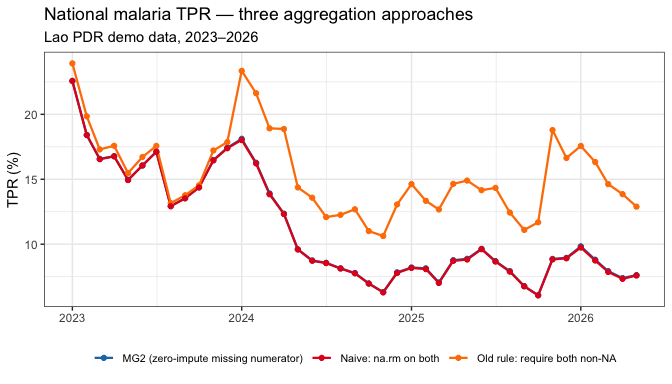

```r
plot_data <- melt(
  national,
  id.vars      = "date",
  measure.vars = c("tpr_mg2", "tpr_paired", "tpr_naive"),
  variable.name = "method",
  value.name    = "tpr"
)
plot_data[, method := fcase(
  method == "tpr_mg2",    "MG2 (zero-impute missing numerator)",
  method == "tpr_paired", "Old rule: require both non-NA",
  method == "tpr_naive",  "Naive: na.rm on both"
)]

ggplot(plot_data, aes(x = date, y = tpr * 100, colour = method)) +
  geom_line(linewidth = 0.8) +
  geom_point(size = 1.5) +
  scale_colour_manual(values = c(
    "MG2 (zero-impute missing numerator)" = "#1f78b4",
    "Old rule: require both non-NA"       = "#ff7f00",
    "Naive: na.rm on both"                = "#e31a1c"
  )) +
  labs(
    title    = "National malaria TPR — three aggregation approaches",
    subtitle = "Lao PDR demo data, 2023–2026",
    x = NULL, y = "TPR (%)", colour = NULL
  ) +
  theme_bw() +
  theme(legend.position = "bottom",
        legend.text = element_text(size = 8))
```

## 5 Comparing MG2 TPR to the DHIS2 indicator

The bundled `dhis2_tpr_national_demo.rds` contains the national-level values of the DHIS2 indicator *MAL - Malaria test positivity rate (Micr+RDT)* (`acDxsQjnEof`), downloaded directly from the analytics API with numerator and denominator included (`includeNumDen = TRUE`). Section 6 shows how this was fetched.

```r
dhis2 <- readRDS(file.path(demo, "dhis2_tpr_national_demo.rds"))
cat("DHIS2 rows:", nrow(dhis2), "\n")
```

```
#> DHIS2 rows: 40
```

```r
head(dhis2)
```

```
#>         date numerator denominator tpr_pct_dhis2
#> 1 2023-01-01      3905       17310          22.6
#> 2 2023-02-01      2940       16092          18.3
#> 3 2023-03-01      2921       17734          16.5
#> 4 2023-04-01      2697       16095          16.8
#> 5 2023-05-01      2714       18168          14.9
#> 6 2023-06-01      3240       20237          16.0
```

```r
mg2_series <- national[, .(date, tpr_mg2 = round(tpr_mg2 * 100, 1))]
dhis2_dt   <- as.data.table(dhis2)[, .(date, tpr_dhis2 = tpr_pct_dhis2)]

compare <- merge(mg2_series, dhis2_dt, by = "date", all = TRUE)
compare
```

```
#> Key: <date>
#>           date tpr_mg2 tpr_dhis2
#>         <Date>   <num>     <num>
#>  1: 2023-01-01    22.6      22.6
#>  2: 2023-02-01    18.4      18.3
#>  3: 2023-03-01    16.6      16.5
#>  4: 2023-04-01    16.8      16.8
#>  5: 2023-05-01    15.0      14.9
#>  6: 2023-06-01    16.1      16.0
#>  7: 2023-07-01    17.1      17.1
#>  8: 2023-08-01    12.9      12.9
#>  9: 2023-09-01    13.5      13.5
#> 10: 2023-10-01    14.4      14.4
#> 11: 2023-11-01    16.5      16.4
#> 12: 2023-12-01    17.4      17.4
```

[output cut: 31 more lines]

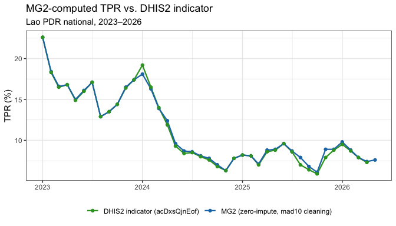

```r
compare_long <- melt(compare, id.vars = "date",
                     variable.name = "source", value.name = "tpr")
compare_long[, source := fifelse(
  source == "tpr_mg2",
  "MG2 (zero-impute, mad10 cleaning)",
  "DHIS2 indicator (acDxsQjnEof)"
)]

ggplot(compare_long, aes(x = date, y = tpr, colour = source)) +
  geom_line(linewidth = 0.8) +
  geom_point(size = 1.5) +
  scale_colour_manual(values = c(
    "MG2 (zero-impute, mad10 cleaning)"  = "#1f78b4",
    "DHIS2 indicator (acDxsQjnEof)"      = "#33a02c"
  )) +
  labs(
    title    = "MG2-computed TPR vs. DHIS2 indicator",
    subtitle = "Lao PDR national, 2023–2026",
    x = NULL, y = "TPR (%)", colour = NULL
  ) +
  theme_bw() +
  theme(legend.position = "bottom")
```

### 5.1 Why do the series differ?

Compare numerators and denominators directly:

```r
mg2_numden <- fac_2023[
  !is.na(denominator) & denominator > 0 & (is.na(numerator) | numerator <= denominator),
  .(mg2_num = sum(fifelse(is.na(numerator), 0, numerator)),
    mg2_den = sum(denominator)),
  by = Month
]
mg2_numden[, date := as.Date(yearmonth(as.character(Month)))]

numden <- merge(
  mg2_numden[, .(date, mg2_num, mg2_den)],
  as.data.table(dhis2)[, .(date, dhis2_num = numerator, dhis2_den = denominator)],
  by = "date"
)
numden[, .(date, mg2_num, dhis2_num, mg2_den, dhis2_den,
           num_ratio = round(mg2_num / dhis2_num, 2),
           den_ratio = round(mg2_den / dhis2_den, 2))]
```

```
#> Key: <date>
#>           date mg2_num dhis2_num mg2_den dhis2_den num_ratio den_ratio
#>         <Date>   <num>     <num>   <num>     <num>     <num>     <num>
#>  1: 2023-01-01    3882      3905   17295     17310      0.99      1.00
#>  2: 2023-02-01    2933      2940   15970     16092      1.00      0.99
#>  3: 2023-03-01    2888      2921   17630     17734      0.99      0.99
#>  4: 2023-04-01    2671      2697   16072     16095      0.99      1.00
#>  5: 2023-05-01    2676      2714   18144     18168      0.99      1.00
#>  6: 2023-06-01    3228      3240   20169     20237      1.00      1.00
#>  7: 2023-07-01    3478      3505   20465     20488      0.99      1.00
#>  8: 2023-08-01    2970      3010   23266     23298      0.99      1.00
#>  9: 2023-09-01    3356      3380   24961     24982      0.99      1.00
#> 10: 2023-10-01    3240      3274   22765     22790      0.99      1.00
#> 11: 2023-11-01    2841      2892   17545     17583      0.98      1.00
#> 12: 2023-12-01    2851      2901   16647     16702      0.98      1.00
```

[output cut: 30 more lines]

The differences trace to several sources:

[output not shown]

## 6 Downloading DHIS2 indicator values directly

The `dhis2_tpr_national_demo.rds` file was downloaded with the following code. This requires a live DHIS2 connection.

```r
library(httr)

base_url  <- "https://demos.dhis2.org/hmis/"
username  <- "demo_en"
password  <- "District1#"   # public demo credentials

# National org unit ID for Lao PDR
nat_ou <- "IWp9dQGM0bS"

# analytics.json with includeNumDen = TRUE returns value, numerator, and denominator
url <- paste0(
  base_url, "api/analytics.json",
  "?dimension=dx:acDxsQjnEof",          # indicator UID
  "&dimension=pe:202301;202302;202303;",
    "202304;202305;202306;202307;202308;202309;202310;202311;202312;",
    "202401;202402;202403;202404;202405;202406;202407;202408;202409;202410;202411;202412;",
    "202501;202502;202503;202504;202505;202506;202507;202508;202509;202510;202511;202512;",
    "202601;202602;202603;202604",
  "&dimension=ou:", nat_ou,
  "&includeNumDen=true",
  "&skipRounding=false",
  "&displayProperty=NAME"
)

resp <- GET(url, authenticate(username, password), timeout(30))
stop_for_status(resp)

d <- content(resp)
# Response columns: indicator UID, period, org unit, value, numerator, denominator, ...
rows <- lapply(d$rows, function(r) data.frame(
  period      = r[[2]],
  value       = as.numeric(r[[4]]),
  numerator   = as.numeric(r[[5]]),
  denominator = as.numeric(r[[6]]),
  stringsAsFactors = FALSE
))
dhis2_tpr <- do.call(rbind, rows)
dhis2_tpr$date <- as.Date(paste0(dhis2_tpr$period, "01"), format = "%Y%m%d")

head(dhis2_tpr)
```

You can also download the underlying raw data elements (what MG2’s `api_data()` uses internally) to inspect DHIS2’s own aggregated counts before the indicator formula is applied:

```r
library(MG2)

elements_df <- data.frame(
  id   = c("enVf9I39FRZ", "vTRrNdOOT9g", "DPNsg3wjxGm", "pmRn0GsUfr6"),
  name = c("MAL - Microscopy positive malaria cases",
           "MAL - RDT positive malaria cases",
           "MAL - Malaria suspects tested with microscopy",
           "MAL - Malaria suspects tested (RDT)"),
  stringsAsFactors = FALSE
)

raw_data <- api_data(
  YrsPrevious = 3,
  orgUnits    = "LEVEL-4",    # district level
  elements    = elements_df,
  baseurl     = base_url,
  username    = username,
  password    = password,
  parallel    = FALSE,
  shinyApp    = FALSE
)
# raw_data has columns: dataElement, period, orgUnit, COUNT, SUM
# COUNT = number of facilities reporting; SUM = aggregate value
head(raw_data)
```

## Summary

| Step | What MG2 does | Why it matters |
| --- | --- | --- |
| Combine step | Sums age/sex categories per facility-month | Collapses disaggregation to one row per facility × month |
| Missing numerator | Imputed to 0 when denominator is valid | Zero positives is plausible; blank entry is common practice |
| Orphaned numerator | Excluded (numerator present, denominator missing/zero) | Cannot compute meaningful TPR; would inflate national numerator |
| Impossible ratio | Excluded (numerator > denominator) | Not biologically possible |
| Reporting tab | Computes weighted average = Σnum / Σden | Correct for ratio data; do not average facility-level TPR values |
| Champion analysis | Based on denominator reporting presence | A facility “shows up” for TPR if it reports total tests, even with zero positives |